# Which EMDE countries excel in green innovation?*

Samuel Edet, Ralf Martin, Golvine de Rochambeau, Trang Thu Tran

08 July 2026

* This post builds on the IFC report [“Innovation in Green Technologies”](https://www.ifc.org/en/insights-reports/2025/innovation-in-green-technologies) and is powered by the [Innovation Strategy Explorer](http://www.prinzproject.io/iseapp) database.

# Introduction

Economic development and the green transition need to go hand in hand. Many of the most dramatic development and growth success stories are built around waves of new technology and innovation such as electronics, wireless and ICT technologies in countries such as Japan, Korea, Taiwan and China. Ukraine is poised to be the world leader in advanced - but cheap - defence technology. Of course, China has also led the way in using the Green Technology Wave as a route to development. Indeed, there is concern that China could be so far advanced in solar or battery technology that not even high-income countries are able to catch up — and that this could impose limitations on sovereignty. However, a challenge of the clean transition is that greenhouse gases are connected to so many human activities. What’s more, we are increasingly facing the challenge of having to adapt to climate change. As a consequence we need to push the innovation frontier in many different technology areas. Thus, there is likely a lot of potential for growth success stories to arise. However, not all countries are equally well placed and not all countries can succeed in the same technologies.

In this dashboard we examine which countries show potential based on their existing innovation landscape as revealed via global patent data. Throughout we assign (patented) innovation to countries on the basis of the location of the associated innovators and the location of the owner (assignee) of the underlying patent.[^1] Our definition of Green includes the full [CPC Y02](https://worldwide.espacenet.com/patent/cpc-browser#!/CPC=Y02) classification, which includes technologies relevant to the mitigation of GHG emissions as well as innovation areas relevant for adaptation to climate change consequences.

# The global green technology innovation landscape

## Figure 1: Green technology innovations and green share per year, by income group

**Universe:** All innovations Multi-country patents

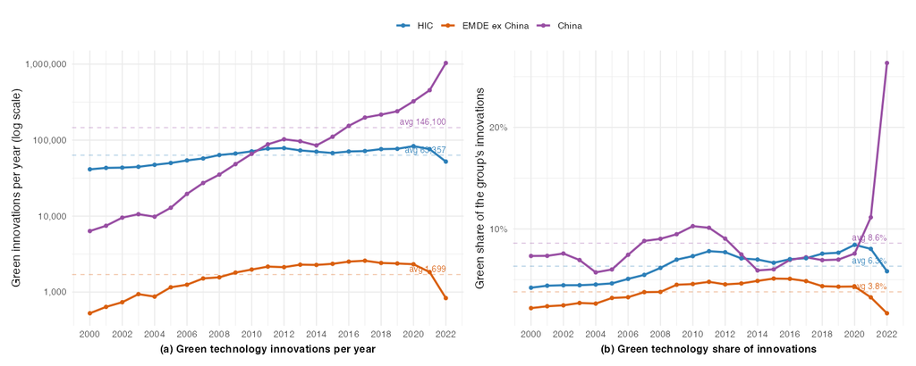

**Note.** Interactive. **Panel (a)** plots the number of green-technology innovations per **family year** (earliest filing year) for the three income groups on a **logarithmic** axis; **panel (b)** plots green technology as a **share** of each group’s total innovation. The faint dashed line in each panel marks that series’ 2000-2022 average (labelled with its value). Innovations are attributed to countries by the union of harmonised inventor + holder locations (patbis2025), one observation per group × family, with the tax-haven rule and the office-of-first- filing fallback for families lacking any person mapping (national offices only; HK/MO folded into CN). The **Universe** toggle switches between **all innovations** and **multi-country patents**.

We explore the relative quality of EMDE green innovations in Figure 2 using several measures derived from direct and indirect citations of patents. We focus on the latest 10 years for which we have data (2013-22). Our first measure is simple citation counts. The value of average spillovers reports a weighted average of the value of all direct and indirect forward patent citations of an innovation; i.e. all innovations that cite a given innovation directly or indirectly.[^3] Thirdly we report an index of marginal spillover returns - i.e. the value that would arise from further R&D investment in a particular technology in a country per amount invested.[^4]

In each case we find:

- EMDE green innovations are of higher quality and economic value than non-green EMDE innovations.
- The quality gap between HIC and EMDE innovation is substantially narrower for green innovation. Indeed, using our preferred measures of Patent Rank and Marginal Spillover Return, we find that green EMDE innovations are of equal or higher quality and economic value than the average HIC innovation.

## Figure 2: Green technology innovation — counts, citations, value and returns by income group (2013-2022)

**Universe:** All innovations Multi-country patents **Metric:**

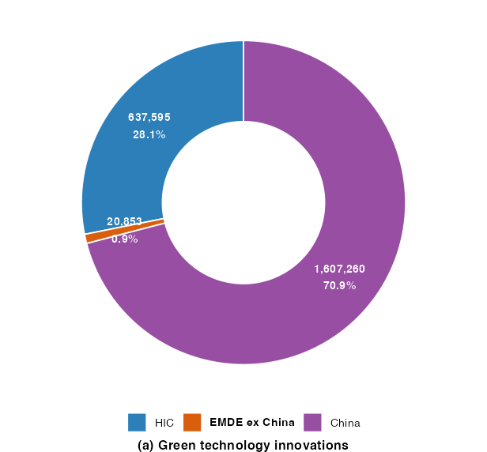

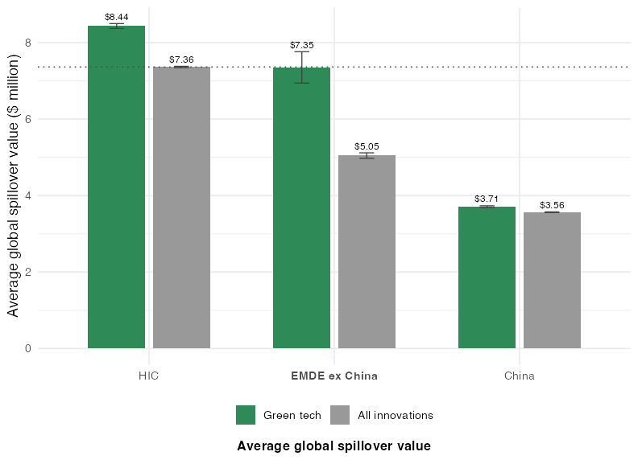

**Note.** Interactive. The **donut** (left) always shows the number of green-technology innovations by income group (total 2,265,708 observations for all innovations). The **Metric** dropdown selects the panel on the right — **average global spillover value** (default; expected global spillover value, **$ million**), **average forward citations per family**, or **average global returns from additional R&D** (the returns-to-R&D index: expected spillover value scaled by R&D cost and patent survival, over innovations with an estimated positive R&D cost, ×100). The **Universe** toggle switches between **all innovations** and **multi-country patents**. All panels attribute innovations to income groups by inventor and owner location, one observation per family within each group. In each metric panel the green and grey bars are green technology vs all innovations, the **dotted horizontal line** marks the HIC all-innovations average as a common reference, and error bars are **95% confidence intervals** for the mean (mean ± 1.96·SE).

# Heterogeneity across countries

The country groupings combine a range of highly diverse countries. Figure 3 explores this heterogeneity with a scatter that compares each country’s green innovation against two benchmarks. The vertical axis plots the country’s green average relative to the global green average; the horizontal axis plots the country’s green average relative to its own average across all technologies. In other words, the vertical axis tells us whether it makes sense to invest in a particular country conditional on wanting to invest in green technology; the horizontal axis tells us whether it makes sense to focus on green technology conditional on focusing on a particular country. The **Measure** dropdown switches the underlying quantity between the average **value of global spillovers** per innovation (default) and the average **global returns to additional R&D** (both as in Figure 2); the **Universe** toggle switches between all and multi-country patents. The three donuts report the share of green innovation that sits in countries above average on the vertical axis, on the horizontal axis, and on both.

A number of developing countries are above one (i.e. above average) on both dimensions — under the returns measure: India, Turkey, Malaysia, Thailand, Vietnam, Iran, Serbia and Indonesia — and a fairly large number more (all with the spillover measure) are above average in terms of local options (horizontal axis).

## Figure 3: Green gap scatter with above-average shares

**Universe:** All innovations Multi-country patents **Measure:**

(a) Green gap scatter — hover a dot for country and values

[interactive chart not shown]

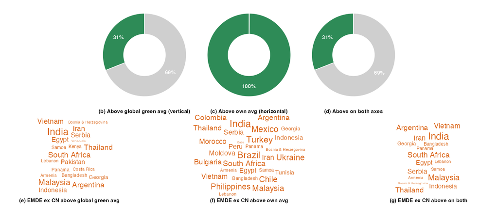

**Note.** Interactive. **Panel (a)** is a scatter over countries with at least 25 green-technology families, each bubble sized by log10(number of green families) — the size legend is labelled with the corresponding actual counts: *x* = the green gap (the country’s green average ÷ its own all-technology average), *y* = the country’s green average relative to the **global green average** (dashed lines mark parity). To keep the plot legible only a subset of countries is labelled, **prioritising the largest EMDE ex China countries by green-family count** (plus the largest HIC and China); **hover any dot** to read its country name, green-innovation count and both axis values. Use the **Measure** dropdown to choose the underlying quantity — average **global spillover value** (default) or average **global returns to R&D** — and the **Universe** toggle for all vs multi-country patents. Bubbles are coloured by country group (HIC, EMDE ex China, China). **Panels (b)-(d)** are donuts giving the share of green innovations (weighted by green families) that sit in countries **above average on the vertical axis** (above the global green average), **above average on the horizontal axis** (above their own all-tech average), and **above average on both axes**. **Panels (e)-(g)** name the **EMDE ex China** countries in each donut’s category: word clouds with font size scaled to log10(green families) (as the scatter bubbles).

Figure 4 shows the location of the inventors and associated firms for innovations with the highest spillover values. To give readers an impression of the exact innovation activities we provide links to the official patent documents in each case. The figures reported above already suggested that the bulk of activity is in HICs and China. However, there are clusters of activity across all continents, although there is a clear under-representation of Africa. That said, there are clusters of high-value green innovative activity in Kenya, Morocco, Egypt and South Africa.

## Figure 4: Where the top green innovations happen

[interactive chart not shown]

**Note.** For every country, its top green innovations that have a **genuine city-level geocode in that country** (inventor location preferred, holder location as fallback; innovations whose only coordinates are capital-city fallbacks are excluded). Each popup links the **country-verified family document** — a publication of the same family on which an inventor or applicant carries this country’s code — so the Espacenet page substantiates the mapping; in the rare case no such document exists, the patent number appears without a link. Innovations are ranked by **global spillover value**; only those **above the whole-sample green average (≈ $4.8 million)** qualify, capped at 100 per country. Dot colour encodes the spillover value on a log scale (green → yellow). A family attributed to several countries appears once per country, always at its location in that country. Same-city innovations are spread in a small circular pattern whose size is fixed **in screen pixels** at city-level zoom — so they remain individually visible as you zoom in and converge on the true location; at wider zooms the spread instead freezes in geographic size, so country- and world-level views are not over-spread; colour encodes the global spillover value ($ million, log scale). **Click** a dot for the patent number (linked to Espacenet), place and value.

# Heterogeneity across technologies

Green technology comprises a wide range of different sub-technologies. What exactly are EMDE innovators doing in this space, and does it differ from what HIC innovators do? We sample 500 of the highest-valued innovations for each group (HIC, EMDE, CN) and divide them into 12 clusters using an unsupervised clustering procedure based on embeddings of the patent abstracts. In Figure 5 this is projected onto a two-dimensional space separately for the country groupings. It is clear that there are differences in focus between the country groupings. Figure 6 shows the distribution across technology clusters for each country grouping. While there is some broad overlap in the frequency of different technologies — e.g. power conversion is a smaller category everywhere and Advanced Materials and Energy Storage is a bigger category throughout — there are some distinct patterns: HICs seem particularly focused on IoT and smart systems. China has a focus on Deep Learning and Image Processing. Other EMDEs diverge with a focus on Catalytic Processes and Materials and Waste Management and Recycling. Figure 6 can also display the distributions for the top 25 innovations across all countries with more than 25 green innovations. This reveals substantial heterogeneity: For instance, Turkey has an unusually strong focus on Advanced Robotics and Automation. The biggest category in India is Advanced Materials for Energy Storage. In Brazil Catalytic Processes and Materials is the biggest category.

**Box 1 — What does EMDE green innovation look like on the ground?** The various figures provided here include many links to the patent documents of high quality green EMDE innovations. Here we select three examples from three different countries.

**India — Council of Scientific and Industrial Research (CSIR)** (WO2014188454). A simple, easily scalable process that turns graphene into two value-added materials at once: nanoporous graphene and graphene quantum dots. The resulting nitrogen-doped porous graphene shows excellent electrochemical activity, making it a low-cost candidate material for fuel cells and energy storage. This is the highest-valued verified EMDE example in our samples (global spillover value ≈ $318 million).

**Brazil — Braskem S.A.** (US2019315948). A bio-based ethylene-vinyl-acetate (EVA) copolymer in which the ethylene is obtained at least in part from renewable carbon sources rather than fossil feedstock. The material matches the flexible, rubber-like hardness range of conventional EVA (Shore A 60–100) while carrying certified bio-based carbon content — a drop-in greener plastic for footwear and other moulded articles (global spillover value ≈ $119 million).

**Kazakhstan — Nazarbayev University Research and Innovation System** (US2020335285). A method for preparing perovskite light-absorber material for solar cells that decouples nucleation from crystallisation, so each step can be controlled independently. This yields highly uniform nucleation sites and hence more uniform perovskite films — addressing one of the main manufacturing hurdles on the road to efficient, low-cost perovskite photovoltaics (global spillover value ≈ $55 million).

## Figure 5: Innovation clusters — top green innovations by global spillover value

[interactive chart not shown]

**Note.** Each panel places a group’s **top green innovations by global spillover value** in the shared embedding/cluster space: **(a)** HIC and **(c)** China show their top-500 samples; **(b)** EMDE ex China pools the developing-country samples and keeps the top 500 by global spillover value. Titles and abstracts are fetched from EPO OPS, embedded (OpenAI `text-embedding-3-small`), clustered into 12 themes (k-means) and projected with UMAP **once**, so coordinates and cluster identities are directly comparable across panels; the legend lists each cluster’s GPT-generated theme and its patent count in the pooled space. **Hover** a point to highlight its cluster within the panel and read its theme and panel count; **click** to open an Espacenet search of that panel’s cluster patents, ranked by global spillover value (only family documents verified to name a party in the panel’s country group are listed).

## Figure 6: Cluster-theme mix of the top green innovations

**Groupings: ▾**

All HIC EMDE ex China China

**Countries: ▾**

Argentina Australia Austria Bangladesh Belarus Belgium Brazil Bulgaria Canada Chile China Colombia Croatia Cyprus Czechia Denmark Egypt Estonia Eswatini Finland France Georgia Germany Greece Hungary Iceland India Indonesia Iran Ireland Israel Italy Japan Kazakhstan Kuwait Latvia Liechtenstein Lithuania Luxembourg Malaysia Malta Mexico Moldova Morocco Netherlands New Zealand Norway Pakistan Peru Philippines Poland Portugal Qatar Romania Russia Samoa Saudi Arabia Serbia Singapore Slovakia Slovenia South Africa South Korea Spain Sweden Switzerland Taiwan Thailand Turkey Ukraine United Arab Emirates United Kingdom United States Vietnam

**Note.** Interactive: the share of each selected series’ green innovations across the 12 shared cluster themes of Figure 5, drawn as **tightly packed grouped bars** — clusters on the vertical axis (ordered by the “All” share), shares on the horizontal; bar thickness adapts to the number of selected series so the chart stays compact, and hovering a bar shows the exact value. The selection dropdowns collapse to a single line after use. **Click** any bar to open an Espacenet search of that series’ top-25 innovations by global spillover value (country-verified family documents for country and group series; the “All” series links the pooled top innovations directly). **Groupings** use the Figure 5 samples — top-500 innovations by global spillover value per group, “All” pooling them. **Countries** (all 74 countries with more than 25 green innovations) use each country’s **top-25** green innovations by global spillover value: those already in the cluster sample keep their cluster, the rest are embedded with the same model and assigned to the **nearest cluster centroid**. Shares sum to 100% within each series; note the different sample depths (top-500 vs top-25) when comparing groupings with countries. Default selection: the three country groups (HIC, EMDE ex China, China), in the same colours used throughout the report; add or remove groupings and countries via the dropdowns.

# Innovating firms and institutions

To understand how to invest in innovation we need to understand who is doing it. Figure 7 reports word clouds of the assignees of the highest-value innovations in the various country groupings. Several results emerge:

- In HICs the top owners are dominated by large — often multinational — firms.
- In China, leading universities and state-affiliated institutions feature prominently alongside firms.
- The list for the developing groups is dominated more by private firms — in some instances firms headquartered in developing countries, but more often than not large multinational firms from HICs.

## Figure 7: Innovation owners — top green innovations by global spillover value

(a) HIC

[figure not shown]

(b) **EMDE ex China**

[figure not shown]

(c) China

[figure not shown]

Owner type: ● company ● university ● research_institute ● government ● other

**Note.** Harmonized patent **owners** of the top green innovations by **global spillover value**, for **(a)** HIC (top-500 sample), **(b)** EMDE ex China (the two developing-group samples pooled, top 500 by global spillover value) and **(c)** China (top-500 sample). The **dropdown menus** above panels (a) and (b) switch the cloud to an **individual HIC or EMDE ex China country**, built from that country’s top-25 green-innovation sample (the same samples behind Figure 6), with owner names harmonised by the same procedure as the pooled panels. Name variants are merged to canonical firms/institutions, individuals dropped, words coloured by entity type and sized by the **log** of the number of patents mapped to the owner (so size differences understate count differences). **Each word is a hyperlink** — clicking it opens an Espacenet search (`pn=` publication numbers) of the top patents by global spillover value mapped to that owner within the panel — listing only family documents verified to name a party in the panel’s country group (for an individual-country cloud, in that specific country). The corresponding innovation **topics** are in the appendix (Figure A1).

# Collaboration in green-technology innovation

The prominent presence of HIC MNEs in EMDE green technology innovation might lead to two opposing concerns.

- Firstly, could this re-direct EMDE innovation capabilities away from EMDE benefits and needs?
- Secondly, while potentially beneficial for EMDE, could this re-direct R&D resources away from more productive outcomes in HICs?

In this section we explore this by looking at the relative quality of innovations by collaboration type between HIC and EMDE institutions and inventors.

## Figure 8: How collaborative is innovation, by group

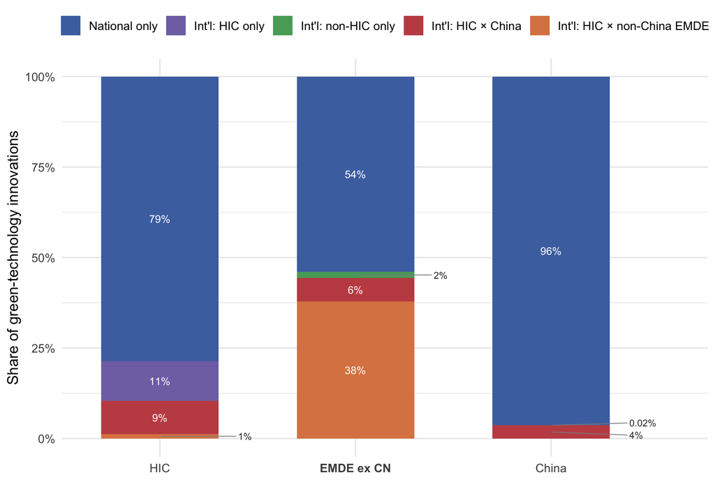

**Note.** Share of each group’s green-technology innovations by inventor-team type (National only, and the four international types by partner income mix — with the North–South mix split into **HIC × China** and **HIC × non-China EMDE**). A family is attributed to a group if it has an inventor in one of that group’s countries (all inventor countries, classified by income — no minimum-size cutoff), so a mixed family appears in several groups and the same international team type has identical mean returns in each group it belongs to; inventor countries come from the geocoded `countrymap` (full coverage, as in the LMICinnovation analysis). For the **HIC** group this separates its developing-world collaboration into the part running through **China** (red) versus the **rest of the developing world** (orange). Some types are structurally absent for a group: the HIC group has no *non-HIC only* teams, and the China / developing groups have no *HIC only* (or, for China, no *HIC × non-China EMDE*) teams. (Green here is the iseapp “Green Technology” tech group.)

The importance of HIC-EMDE collaborations for EMDE becomes even more pronounced when looking at the spillover values of innovations (Figure 9a). Collaborations between HIC and EMDE innovators are over 4 times more valuable than entirely domestic EMDE innovations (centre grouping in Figure 9a). Collaborations between Chinese and other EMDE innovators are even more valuable. A similar ranking emerges when looking at spillover values where the recipients of spillovers are other EMDE innovators. This would suggest that such collaborations are not only beneficial to HIC partners or other HIC firms but also to EMDE by increasing the flows of knowledge spillovers in EMDE economies as a whole.

Similarly, we can compare HIC-EMDE collaborations to international collaborations between innovators in different HIC countries, or to domestic HIC innovations. We find that HIC-EMDE collaborations are of similar value to HIC-HIC collaborations and of higher value than purely domestic HIC innovations. In other words, there is no evidence of the second concern raised above. Looking at this in terms of marginal returns (using the dropdown menu) leads to a similar assessment.